# R Notebook

# COVID PHU-Level Clustering

## Hierarchical Clustering Methods

### Agglomerative Clustering:

Data is first scaled then the euclidean distance is computed between each PHU. Clusters are formed based on least dissimilarities between observations.

*Group average clustering:* attempts to produce relatively compact that are relatively far apart. *Complete clustering:* all union observations for two groups are least dissimilar - can produce clusters that violate “closeness” property (one observation may be more similar to observations in other groups). *Single clustering:* grouped based on one dissimilarity measure common between two observations being very small - prone to chaining.

Single linkage appears to have chaining while average linkage groups are not as easily discernable. Complete linkage was chosen for further analysis.

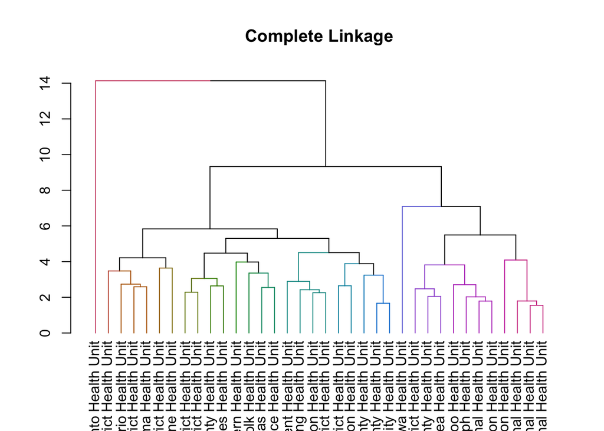

With 8 groups it seems as though there is too much separation…

| cluster | n |
| --- | --- |
| 1 | 4 |
| 2 | 1 |
| 3 | 1 |
| 4 | 7 |
| 5 | 5 |
| 6 | 8 |
| 7 | 4 |
| 8 | 6 |

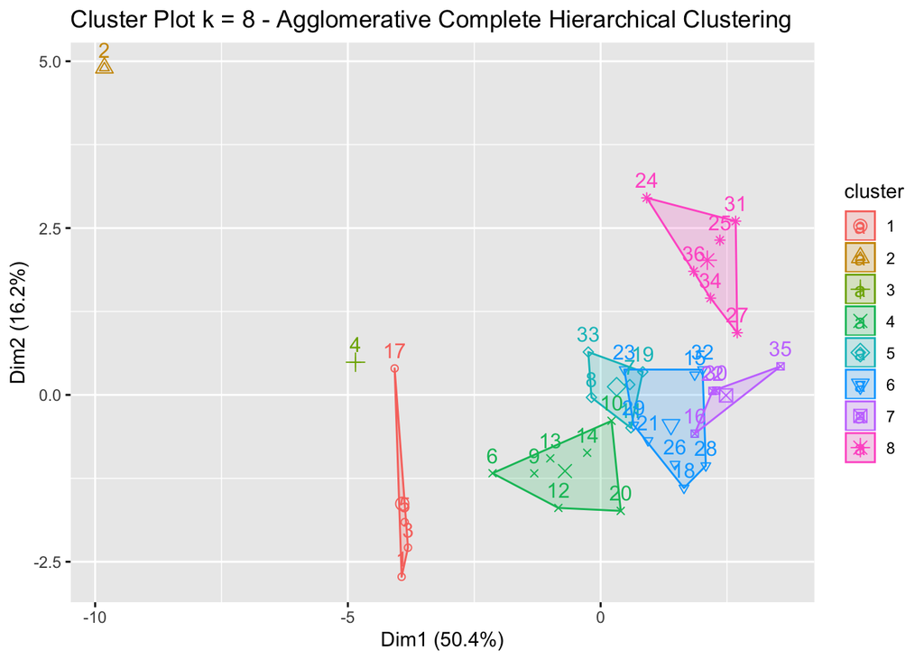

| cluster | n |
| --- | --- |
| 1 | 35 |
| 2 | 1 |

[figure not shown]

The agglomerative coefficient for complete linkage:

```
## [1] "Aggloemeratice Coefficient:  0.788263842913261"
```

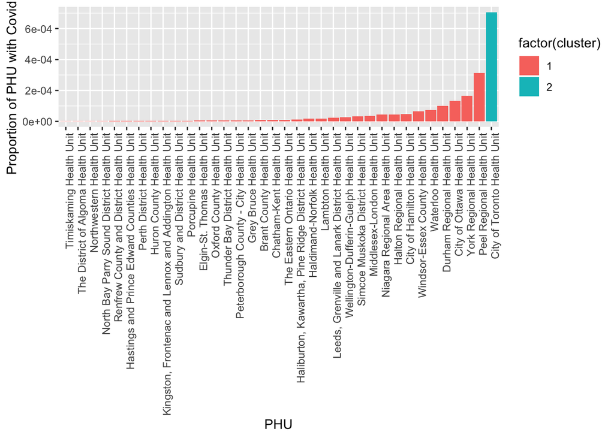

### Divisive Hierarchical Clustering - DIANA

All observations begin as a single cluster and are divisible separated based on largest average dissimilarity between an observation and all others.

Hierarchical clustering will always cluster even if there is no grouping in the data. The divisive coefficient is on a 0-1 scale, representing the extent to which the hierarchical structure produced by a dendrogram actually represents the data (closer to 1 = better representation).

```
## [1] "Divisive Coefficient:  0.783956629341799"
```

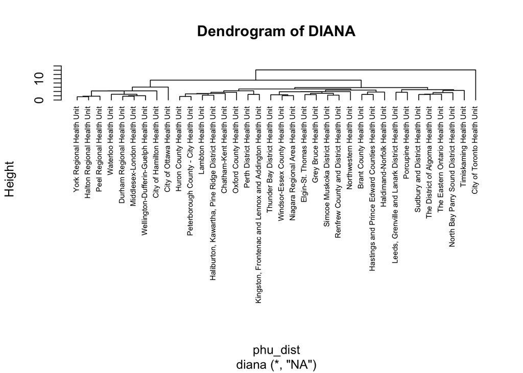

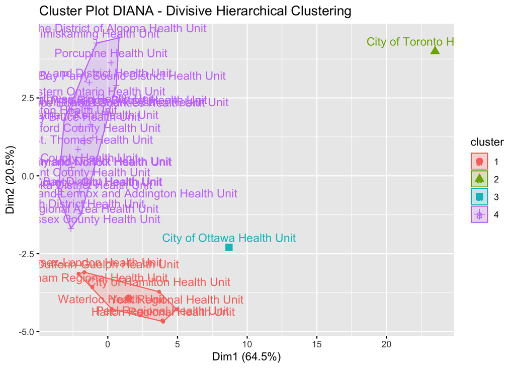

Covid Case Total Proportions (per PHU) data and DIANA cluster assignment are added to `phu_prop` to assess groupings by covid output.

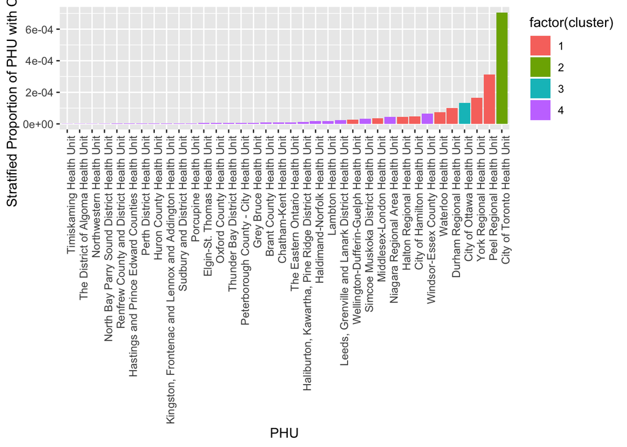

Looking at covid case proportions for each PHU coloured by transit proximity.

Peel and York have week transit proximity but high case proportions.

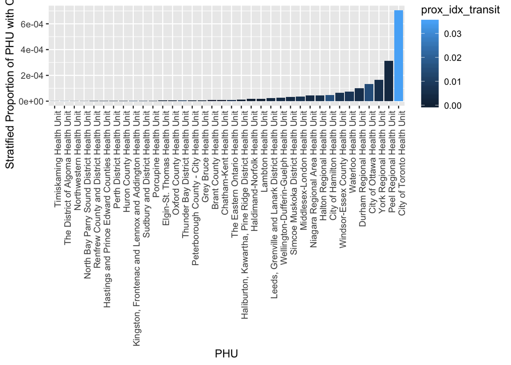

```r
phu_cl <- mutate(phu_prop, CovidCaseStrat = phu$TotalStratified)

ggplot(phu_cl, aes(x=fct_reorder(Location,CovidCaseStrat, .desc=F), y = CovidCaseStrat, fill = prox_idx_transit)) +
  geom_bar(stat="identity")  +
  theme(axis.text.x=element_text(angle=90,hjust=1)) +
  labs(x = "PHU", y = "Stratified Proportion of PHU with Covid Cases")
```

## Mixture Model Clustering Methods

### EM Algorithm

Soft version of K-means clustering that is based on probabilities rather than deterministic assignments of points to groups. Used package `Mclust`.

Between PHU and Stratified Proportion of Cases:

```r
# EM view clasess ----
classes <- mutate(as.data.frame(mcovid$classification), loc = phu$Location)
colnames(classes)[1] <- 'class'
classes <- classes[order(classes),][1:36,]
classes
```

|  | class | loc |
| --- | --- | --- |
| 10 | 1 | Thunder Bay District Health Unit |
| 15 | 1 | Northwestern Health Unit |
| 1 | 2 | York Regional Health Unit |
| 2 | 2 | City of Toronto Health Unit |
| 3 | 2 | Halton Regional Health Unit |
| 4 | 2 | City of Ottawa Health Unit |
| 5 | 2 | Peel Regional Health Unit |
| 6 | 2 | Waterloo Health Unit |
| 7 | 2 | Huron County Health Unit |
| 8 | 2 | Perth District Health Unit |

[output cut: 26 more lines]

### Multidimensional Scaling

Uses euclidean distances of scaled PHU data. Similarly represents hierarchical clustering (Toronto is its own cluster, denser regions such as Peel, Halton, York, Waterloo, Ottawa…etc. separate from smaller districts).

```r
labels(phu_dist)
```

```
##  [1] "York Regional Health Unit"
##  [2] "City of Toronto Health Unit"
##  [3] "Halton Regional Health Unit"
##  [4] "City of Ottawa Health Unit"
##  [5] "Peel Regional Health Unit"
##  [6] "Waterloo Health Unit"
##  [7] "Huron County Health Unit"
##  [8] "Perth District Health Unit"
##  [9] "Durham Regional Health Unit"
## [10] "Thunder Bay District Health Unit"
## [11] "Peterborough County - City Health Unit"
## [12] "Middlesex-London Health Unit"
## [13] "Wellington-Dufferin-Guelph Health Unit"
## [14] "Windsor-Essex County Health Unit"
## [15] "Northwestern Health Unit"
```

[output cut: 21 more lines]

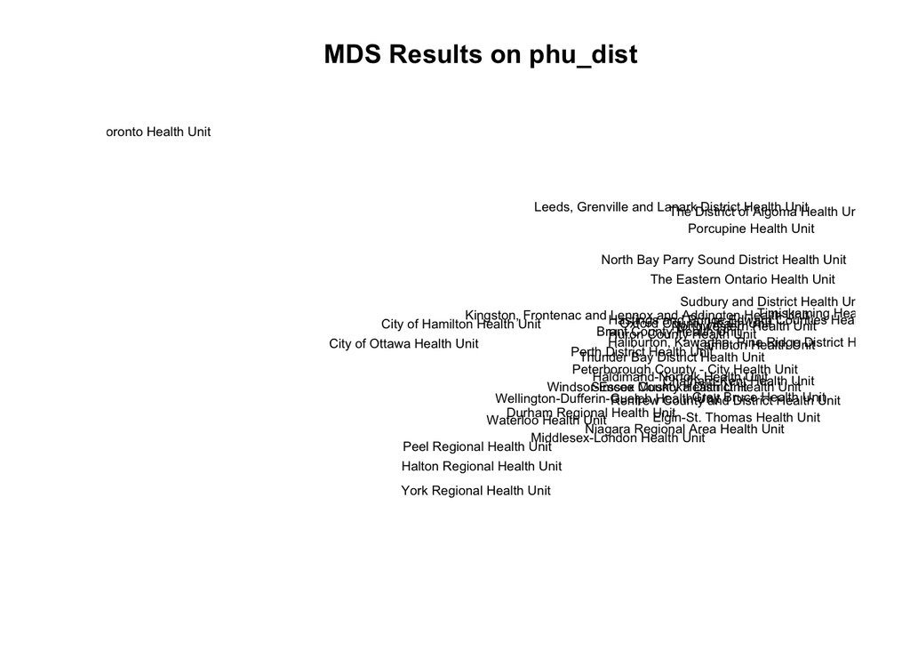

```r
plot(cmdscale(phu_dist)[,1], cmdscale(phu_dist)[,2], type = "n",
     xlab = "", ylab = "",
     asp = 1, axes = FALSE,
     main = "MDS Results on phu_dist")
text(cmdscale(phu_dist)[,1], cmdscale(phu_dist)[,2], rownames(cmdscale(phu_dist)), cex = 0.6)
```

# Clustering with only `amenity` cols

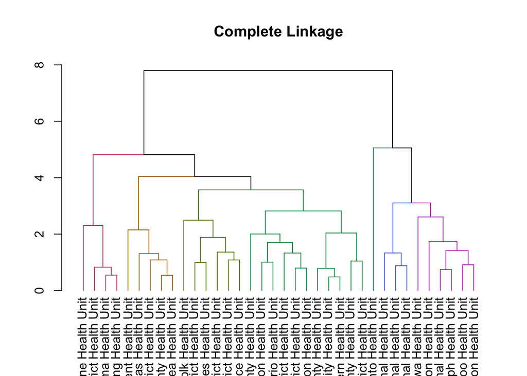

```r
amenity_keep <- c('Location', 'asthma.percent', 'copd.percent', 'hbp.percent', 'smokers.percent', 'amenity')

phu_amen <- subset(phu, select = amenity_keep)

rownames(phu_amen) <- phu_amen$Location
```

```r
# 2 clusters according to previous plot ----
phu_amen_cl <- mutate(phu_amen, cluster = cutree(comp2, k = 2))
count(phu_amen_cl,cluster)
```

| cluster | n |
| --- | --- |
| 1 | 10 |
| 2 | 26 |

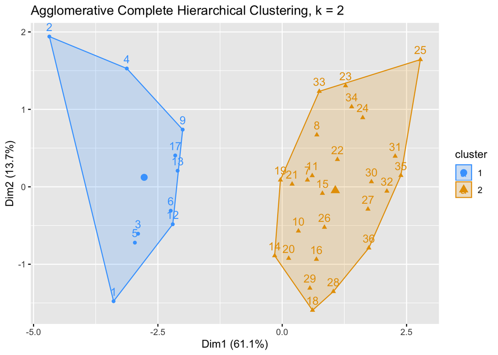

```r
# VIS: cluster groups ----
fviz_cluster(list(data = phu_amen_cl[,-1], cluster = cutree(comp2, k = 2)),
             main = "Agglomerative Complete Hierarchical Clustering, k = 2")+   scale_colour_manual(values=c("#46A5FE", "#E69F00")) +
  scale_fill_manual(values=c("#46A5FE", "#E69F00"))
```

The agglomerative coefficient for complete linkage:

```
## [1] "Aggloemeratice Coefficient:  0.841857838423617"
```

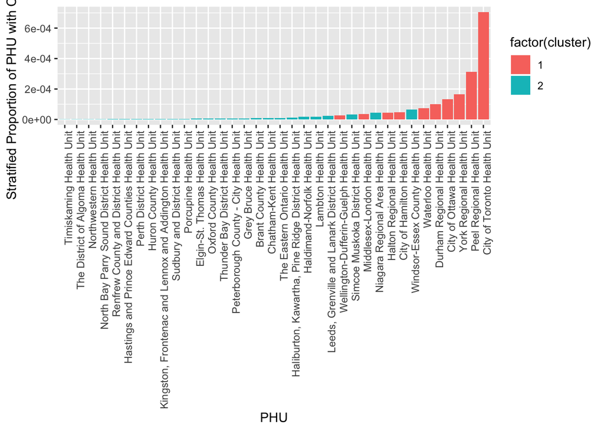